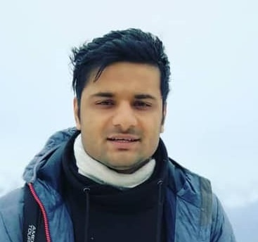

# About Myself

With a rich educational background spanning from a Bachelor’s degree in Forestry to a Master’s in Landscape Ecology and Nature Conservation, supplemented by practical experiences in forest management and carbon monitoring, I am driven by a passion for contributing to climate science and environmental conservation efforts.

# Education

| Duration | Course | University | Country |
| --- | --- | --- | --- |
| 2017 - 2019 | M.Sc. Landscape Ecology and Nature Conservation | University of Greifswald | Germany |
| 2010 - 2013 | B.Sc. Forestry | Tribhuvan University | Nepal |
| 2007 - 2009 | Technical Level in Forestry (I.Sc.) | Tribhuvan University | Nepal |

# Work Experiences

| Year | Affiliation and Duties |
| --- | --- |
| 2017 - 2019 | M.Sc. Landscape Ecology and Nature Conservation, Greifswald University |
| 2019 - 2023 | Assistant Research Officer, Forest Survey and Carbon Monitoring Section under FRTC |
| 2023 - Present | Research Officer, Climate Change Management Division, MOFE |
| Part-time | Lecturer, Natural Resource Economics, Kathmandu Forestry College |

# Major Skills

- National Forest data analysis and Reporting
- Mastering MS. Excel and R programming
- Carbon accounting and MRV process
- Uncertainty Estimation and Sensitivity Analysis
- Data Science with Python
- GIS Tools (QGIS, ARCGIS, Google Earth Engine etc.)

# Major Job-Related Trainings as Trainee

| Year | Entitled |
| --- | --- |
| 2022 | Training on Unbiased Area Estimation and Uncertainty Estimation for Forest Activity Data |
| 2022 | Development of National Landcover Monitoring System for Nepal |
| 2022 | On the Job training on Forest Carbon Stock Measurement using Earth Observation Data |
| 2023 | Data Science with Python |

# Major Job-Related Trainings as Trainer

| Duration | Entitled |
| --- | --- |
| Regular | MS Excel and R Programming Trainer |
| 2023 | Training on Python Programming |
| 2023 | Statistical Data Analysis and Forest Mapping |
| 2024 | Enhancing Capacity on R Programming for Data Analysis and Carbon Accounting |

# Workshop and Seminar

1. Cross Country knowledge Exchange on REDD plus program in Cambodia dated from 12/06/2022 to 19/06/2022 Phnom Penn, Siem Reip and Koh Kong province of Cambodia (ORAL PRESENTATION)
2. South-South Knowledge Exchange on Measurement, Monitoring, Reporting and Verification systems, FCPF CF ERPA Implementation

# Research Experience

1. Preparation of National Landcover monitoring System (NLCMS) using RandomForestClassifier.
2. FRTC, 2020, A study of Opportunities and Constraints for Development of Private forestry Model in Mid-Hill Region of Nepal (A case study from Kavre and Kaski district of Nepal), Forest Research and Training Centre (FRTC), Babarmahal, Kathmandu, Nepal. Unpublished
3. Preparation of Regional and National Forest Resource assessment (Involvement in field data collection, data analysis and report writing).
4. Involvement in generating activity data and emission factors for national emission reduction report for MRV purpose in coordination with FCPF and World Bank.

# Publications

1. Aryal, S., Paudel, P., Bolakhe, S., Mahatara, D., & Lamichhane, P. (2022). Evaluation of error and efficiency on tree height measurement using Abney’s level, Rangefinder and Vertex IV. *Indian Journal of Forestry*, 45(1), 1–8. [DOI](https://doi.org/10.54207/bsmps1000-2022-49P4F8)
2. Parajuli, A., Gautam, A. P., Sharma, S., Lamichhane, P., Sharma, G., Bist, B. S., Aryal, U., & Basnet, R. (2022). A Strategy for involving community forest managers in effective forest fire management in Nepal. *Banko Janakari*, 32(1), 41–51. [DOI](https://doi.org/10.3126/banko.v32i1.45476)
3. Subedi, B., Lamichhane, P., Magar, L. K., & Subedi, T. (2022). Aboveground carbon stocks and sequestration rates of forests under different management regimes in Churia region of Nepal. *Banko Janakari*, 32(1), 15–24. [DOI](https://doi.org/10.3126/banko.v32i1.45442)
4. Gautam, G. P., Aryal, R. R., & Lamichhane, P. (2018). Restoration of degraded land through Moso bamboo (Phyllostachys pubescens) plantation in the Mid-hills of Nepal. *Banko Janakari*, 150–153. [DOI](https://doi.org/10.3126/banko.v27i3.20560)
5. Dhakal, R., et al. (2023). Developing Stem Taper of Shorea Robusta in the Far-Western Terai of Nepal. *Banko Janakari*, 33(2), 3–10. [DOI](https://doi.org/10.3126/banko.v33i2.58809)

# Contact

**Prakash Lamichhane**  
Research Officer/ Data Analyst  
Ministry of Forest and Environment

- Email: forester.prakash@gmail.com
- Phone: +977-9845228896
- GitHub: foresterprakash
- LinkedIn: PrakashLamichhane
- ORCID: 0000-0002-0355-0222